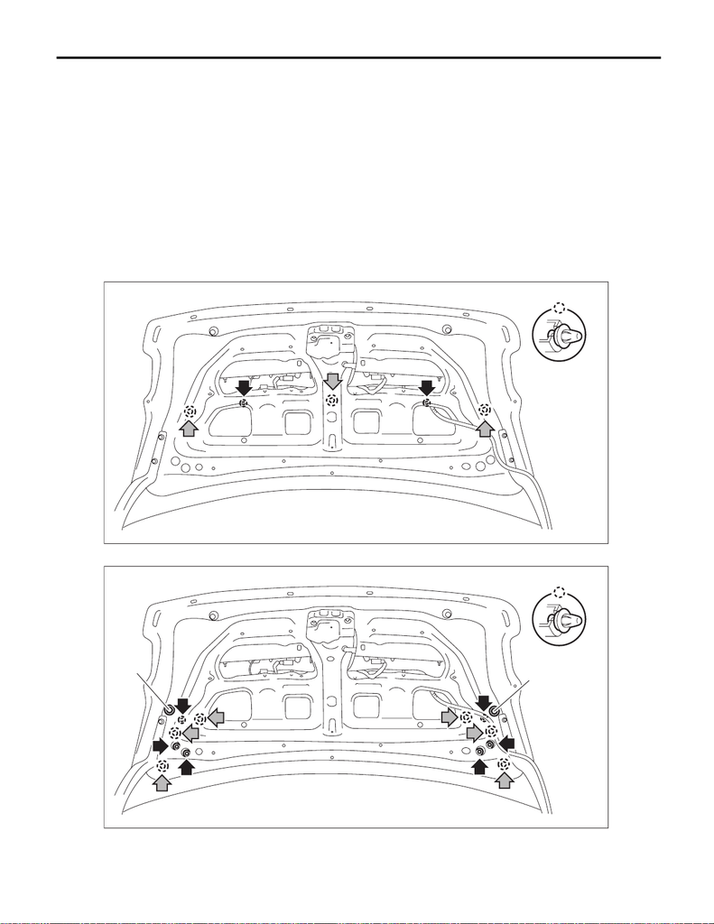

EI-52

Rear Spoiler

EXTERIOR/INTERIOR TRIM

14.Rear Spoiler

A: REMOVAL

1) Remove the trim panel - trunk lid. <Ref. to EI-95, REMOVAL, Trunk Room Trim.>

2) Detach the rear spoiler assembly.

CAUTION:

• When removing the nut, be careful not to drop the nut inside the trunk lid panel.

• Be careful not to damage the vehicle body during removal and installation.

(1) Remove the plugs (a). (Model with large rear spoiler)

(2) Remove the nuts.

(3) Disengage the clips and remove the rear spoiler assembly.

• Model with small rear spoiler

• Model with large rear spoiler

EI-04311

EI-04303

(a)

(a)

[figure not shown]

EI-53

Rear Spoiler

EXTERIOR/INTERIOR TRIM

B: INSTALLATION

1) Clean the trunk lid and spoiler attachment surface before installation.

CAUTION:

Make sure that there is a gasket attached on the clip of the rear spoiler assembly. If a gasket is not

attached, water leakage may occur.

2) Install the rear spoiler assembly.

Tightening torque:

7.5 N·m (0.8 kgf-m, 5.5 ft-lb)